# Latihan 5 MPDW

## Library

```r
library(forecast)
```

```r
library(ggplot2)
library(tsibble)
library(tseries)
library(MASS)
```

## Import Data

```r
data <- read.csv("D:\\File\\Data Science\\Semester 5\\MPDW\\Data MPDW Kelompok 1.csv")
df <- data[126:250, ]
df
```

```
##           Date     Close    Volume
## 126 2024-04-22  7619.253  23379200
## 127 2024-04-23  7294.498  14117500
## 128 2024-04-24  7968.989  16627200
## 129 2024-04-25  8268.763  16941200
## 130 2024-04-26  8618.499  36478400
## 131 2024-04-29  9018.197  17974400
## 132 2024-04-30  9218.047  24471600
## 133 2024-05-02  9867.557  22657200
## 134 2024-05-03  9867.557         0
## 135 2024-05-06  9292.990  13332100
## 136 2024-05-07  9867.557  13495400
## 137 2024-05-08  9642.727  12895300
## 138 2024-05-13  9442.877  12510700
## 139 2024-05-14  9268.010  11060200
```

[output cut: 111 more lines]

Data yang digunakan adalah data saham BREN hari ke-126 hingga hari ke-250

## Eksplorasi Data

```r
mean <- mean(df$Close)
mean
```

```
## [1] 8897.535
```

```r
var(df$Close)
```

```
## [1] 2115965
```

## Pemeriksaan Kestasioneran Data

### Plot Time Series

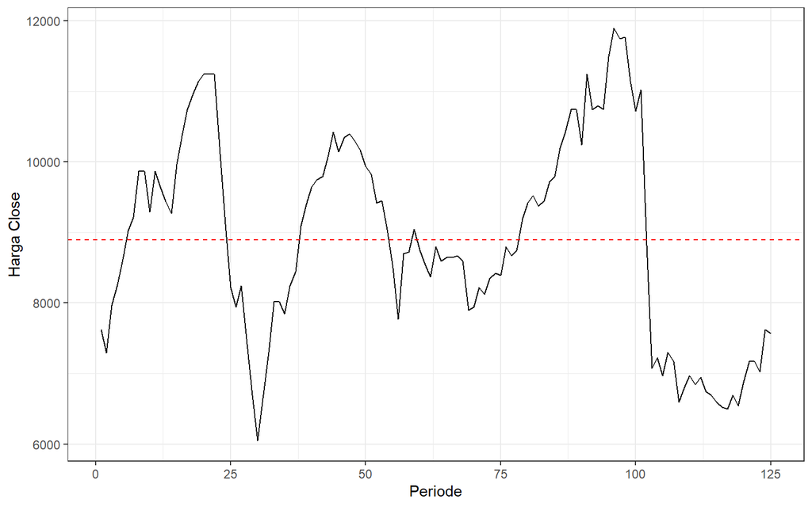

```r
dt <- ts(df$Close)

plot <- dt |> as_tsibble() |>
  ggplot(aes(x = index, y = value)) + geom_line() + theme_bw() +
  geom_hline(yintercept = mean, color = "red", linetype = "dashed") +
  xlab("Periode") + ylab("Harga Close")
plot
```

Pada plot deret waktu diatas terlihat bahwa data tidak stasioner baik dalam rataan yang ditandai dengan adanya tren yang berfluktuasi dan jauh dari nilai rataannya $8897.535$ serta dalam ragam, yang ditandai dengan perbedaan pelebaran pita pada plot.

### Plot ACF

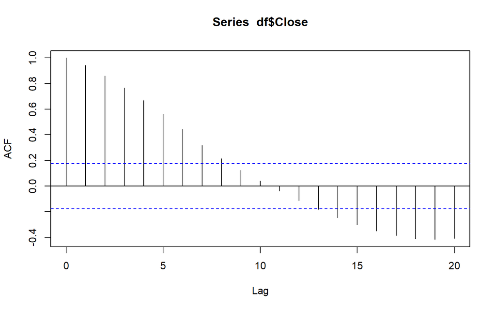

```r
acf(df$Close)
```

Terlihat bahwa plot ACF diatas membentuk pola tails off dan cenderung membentuk pola grafik sinus. Dari plot ini diperlukan adanya uji lanjut untuk memastikan kestasioneran datanya.

### Uji ADF

$H_0:Data \ Tidak \ Stasioner \ dalam \ Rataan$  
$H_1:Data \ Stasioner \ dalam \ Rataan$

```r
tseries::adf.test(df$Close)
```

```
##
##  Augmented Dickey-Fuller Test
##
## data:  df$Close
## Dickey-Fuller = -2.9387, Lag order = 4, p-value = 0.1865
## alternative hypothesis: stationary
```

Hasil Uji ADF memperlihatkan nilai $p-value$ sebesar $0.1865$ yang lebih besar dari $\alpha=0.05$ sehingga Tak Tolak $H_0$ yang artinya data tidak stasioner dalam rataan, sesuai dengan plot ACF diatas.

### Kestasioneran dalam Ragam

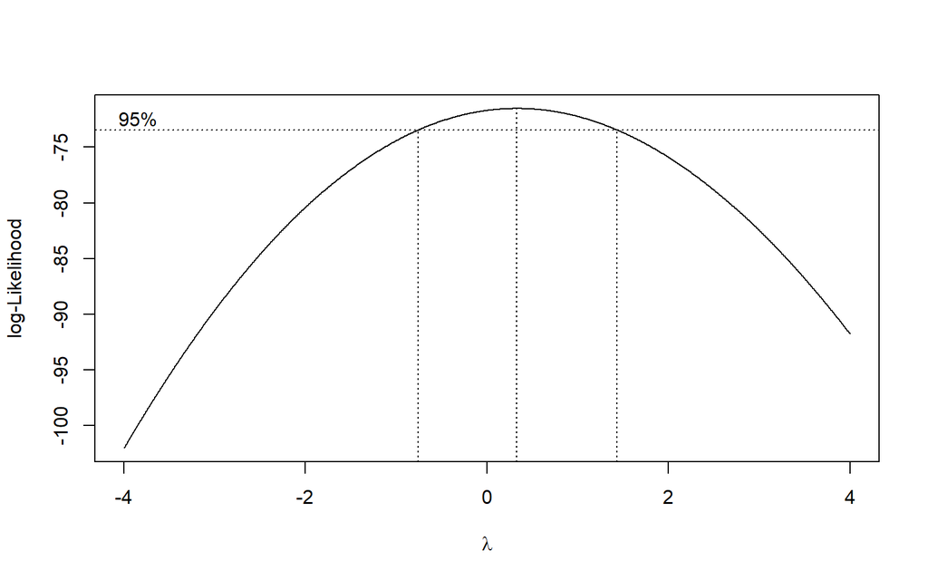

```r
index <- seq(126:250)
bc = boxcox(df$Close~index, lambda = seq(-4,4,by=0.01))
```

```r
lambda <- bc$x[which.max(bc$y)]
lambda
```

```
## [1] 0.33
```

```r
ci_lambda <- bc$x[bc$y > max(bc$y) - 0.5 * qchisq(0.95, 1)]

ci_lower <- min(ci_lambda)
ci_upper <- max(ci_lambda)

c(Batas_Bawah = ci_lower, Batas_Atas = ci_upper)
```

```
## Batas_Bawah  Batas_Atas
##       -0.75        1.43
```

Hasil uji Box–Cox menunjukkan bahwa nilai $λ$ optimum adalah $0.33$. Pada selang kepercayaan diatas terlihat bahwa nilai batas bawah sebesar $-0.75$ dan batas atas sebesar $1.43$, sehingga nilai $\lambda=1$ berada dalam selang tersebut, artinya data stasioner dalam ragam.

## Penanganan Ketidakstasioneran Data

### Differencing I

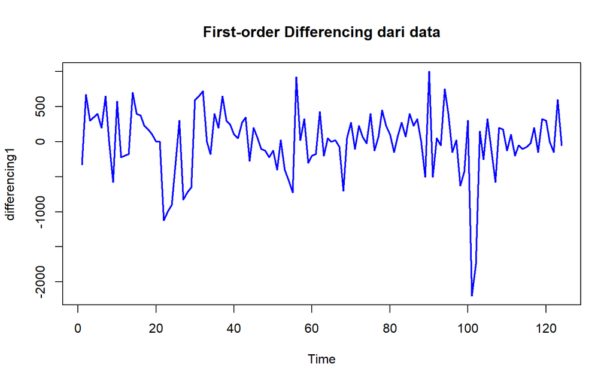

```r
differencing1 <- diff(df$Close, differences = 1)

ts.plot(differencing1,
        main = "First-order Differencing dari data",
        col = "blue", lwd = 2)
```

```r
length(differencing1)
```

```
## [1] 124
```

Setelah dilakukan proses differencing, terlihat bahwa data cenderung stasioner dalam rataan, namun hal tersebut masih perlu dipastikan melalui plot ACF dan Uji ADF.

### Plot ACF setelah Penanganan

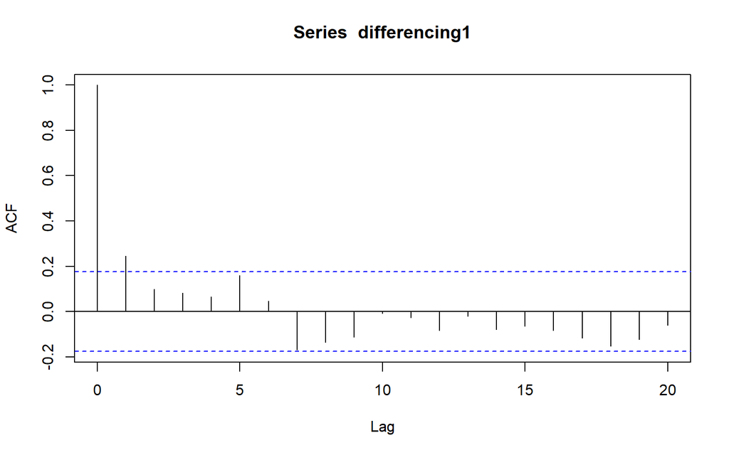

```r
acf(differencing1)
```

Pada plot ACF diatas terlihat bahwa tidak plot tidak mengalami penurunan perlahan (tails off) hanya saja masih signifikan di lag ke-1, tetapi secara keseluruhan plot ACF ini menggambarkan bahwa data sudah stasioner dalam rataan yang akan dibuktikan pada uji ADF.

### Uji ADF setelah Penanganan

```r
adf.test(differencing1)
```

```
##
##  Augmented Dickey-Fuller Test
##
## data:  differencing1
## Dickey-Fuller = -3.6151, Lag order = 4, p-value = 0.03482
## alternative hypothesis: stationary
```

Hasil Uji ADF memperlihatkan nilai $p-value$ sebesar $0.03482$ yang lebih kecil dari $\alpha=0.05$ sehingga Tolak $H_0$ yang artinya data stasioner dalam rataan, sesuai dengan plot ACF diatas.

### Kestasioneran dalam Ragam setelah Penanganan

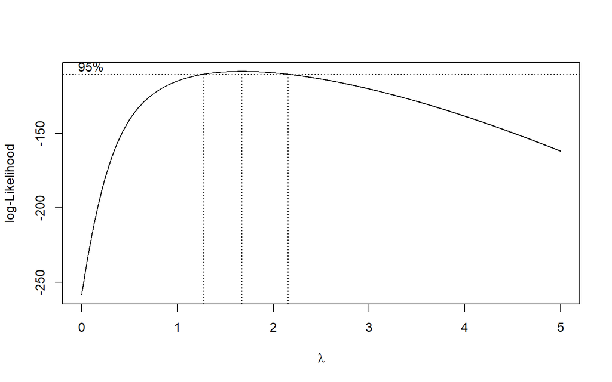

```r
index2 <- seq(126:249)

bc <- boxcox(
  differencing1 - min(differencing1) + 1 ~ index2,
  lambda = seq(0, 5, by = 0.001)
)
```

```r
lambda <- bc$x[which.max(bc$y)]
lambda
```

```
## [1] 1.671
```

```r
ci_lambda <- bc$x[bc$y > max(bc$y) - 0.5 * qchisq(0.95, 1)]

ci_lower <- min(ci_lambda)
ci_upper <- max(ci_lambda)

c(Batas_Bawah = ci_lower, Batas_Atas = ci_upper)
```

```
## Batas_Bawah  Batas_Atas
##       1.269       2.153
```

Hasil uji Box–Cox menunjukkan bahwa nilai $λ$ optimum adalah $1.671$ dengan selang kepercayaan (1.269 2.153). Karena selang tersebut tidak memuat nilai $λ = 1$, maka dapat disimpulkan bahwa data tidak stasioner dalam ragam sehingga diperlukan transformasi.

### Transformasi Box-Cox

```r
y_shift <- differencing1 - min(differencing1) + 1
y_bc <- y_shift^2
```

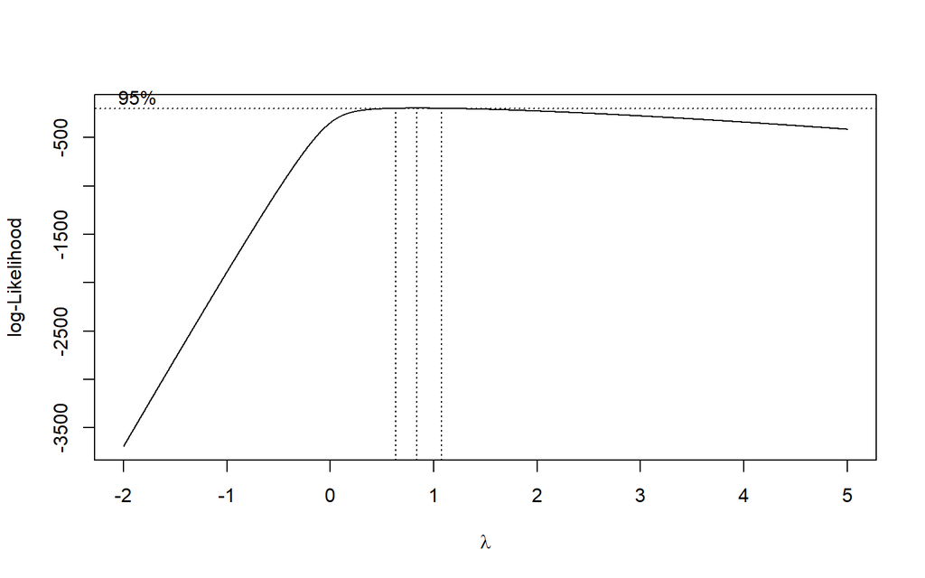

```r
index <- seq(126:249)

bc <- boxcox(
  y_bc ~ index,
  lambda = seq(-2, 5, by = 0.001)
)
```

```r
lambda <- bc$x[which.max(bc$y)]
lambda
```

```
## [1] 0.835
```

```r
ci_lambda <- bc$x[bc$y > max(bc$y) - 0.5 * qchisq(0.95, 1)]

ci_lower <- min(ci_lambda)
ci_upper <- max(ci_lambda)

c(Batas_Bawah = ci_lower, Batas_Atas = ci_upper)
```

```
## Batas_Bawah  Batas_Atas
##       0.635       1.076
```

Hasil uji Box–Cox menunjukkan bahwa nilai $λ$ optimum adalah $0.835$. Pada selang kepercayaan diatas terlihat bahwa nilai batas bawah sebesar $0.635$ dan batas atas sebesar $1.076$, sehingga nilai $\lambda=1$ berada dalam selang tersebut, artinya data sudah stasioner dalam ragam.